# BIOEE 3550/6550 : **Data analysis and visualization in ecology and environmental science**

### *Spring 2025*

### Instructor: **Xiangtao Xu** ( ✉️ xx286@cornell.edu)

### Teaching Assistant: **Yixin Ma** (✉️ ym524@cornell.edu)

## Lab 1 *Organize Tabular Data and Probability*

In this Lab, we will introduce typical workflow to explore tabular data (e.g., `csv` or `xlsx` files). The main learning objectives of today include:

- Access tabular data with commonly used packages/API
- Practice indexing, subsetting, and grouping that are useful for data cleaning/preparation before further analysis
- Generate histogram plots and descriptive statistics
- Overlay/Fit theoretical distributions based on observed data

**For R users**, please install necessary packages by running the following commands in your console `install.packages('tidyverse','MASS','ggplot2',dep=TRUE)`

### 0. Codes used in lecture

This section contains code and figure examples mentioned in the course, using `lab1_rainfall.csv` (available on Canvas).

#### 0.1 Read data

```r
library(tidyverse) # load the packages

df_rain <- read_csv('./lab1_rainfall.csv')# read csv file
# for excel spreadsheet, use read_excel

print(head(df_rain,10))
```

```
## # A tibble: 10 × 3
##    col1          col2  col3
##    <chr>        <dbl> <dbl>
##  1 Jan 1, 2000   0     2000
##  2 Jan 2, 2000   0     2000
##  3 Jan 3, 2000   3.71  2000
##  4 Jan 4, 2000  26.0   2000
##  5 Jan 5, 2000   0     2000
##  6 Jan 6, 2000   0     2000
##  7 Jan 7, 2000   0     2000
##  8 Jan 8, 2000   0     2000
##  9 Jan 9, 2000   1.94  2000
## 10 Jan 10, 2000  3.87  2000
```

```r
# print first 10 columns

summary(df_rain)
```

```
##      col1                col2              col3
##  Length:8400        Min.   :  0.000   Min.   :2000
##  Class :character   1st Qu.:  0.000   1st Qu.:2005
##  Mode  :character   Median :  0.000   Median :2011
##                     Mean   :  2.892   Mean   :2011
##                     3rd Qu.:  0.000   3rd Qu.:2017
##                     Max.   :134.538   Max.   :2022
```

```r
# print descriptive statistics
```

#### 0.2 Histogram of rainfall amounts

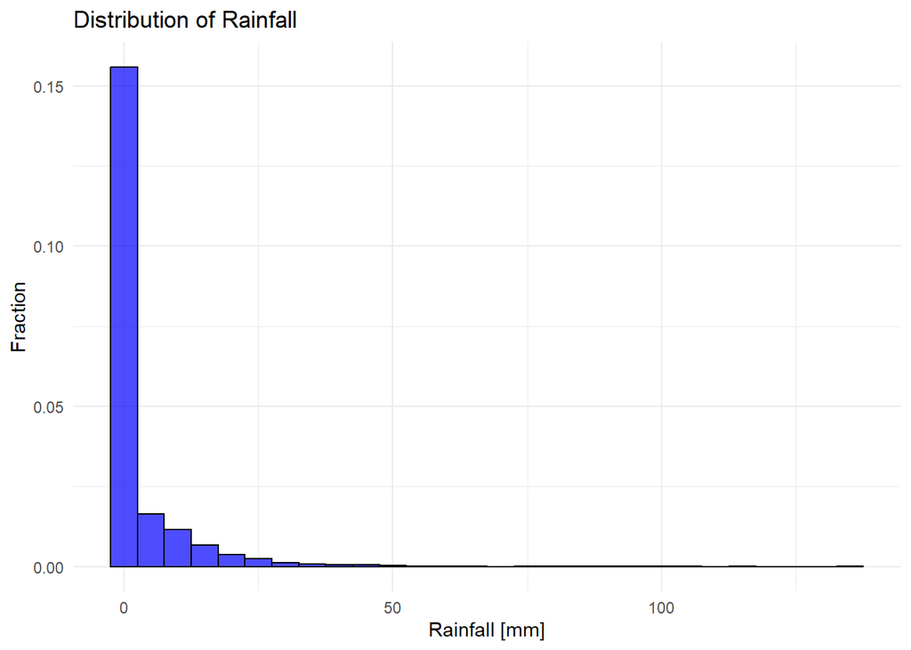

```r
library(ggplot2)
# load the plotting package

# Create a histogram using ggplot2
ggplot(df_rain, aes(x = col2, y=after_stat(density))) +
  # y=after_stat(density) means that we are plotting the proportion/frequency
  # if we remove y=after_stat(density), then y axis is number of occurrence
  geom_histogram(binwidth=5,
                 fill = "blue", alpha = 0.7, color = "black")+
  labs(x = "Rainfall [mm]", y = "Fraction",
       title = "Distribution of Rainfall") +
  theme_minimal()
```

#### 0.3 Box plot and descriptive statistics

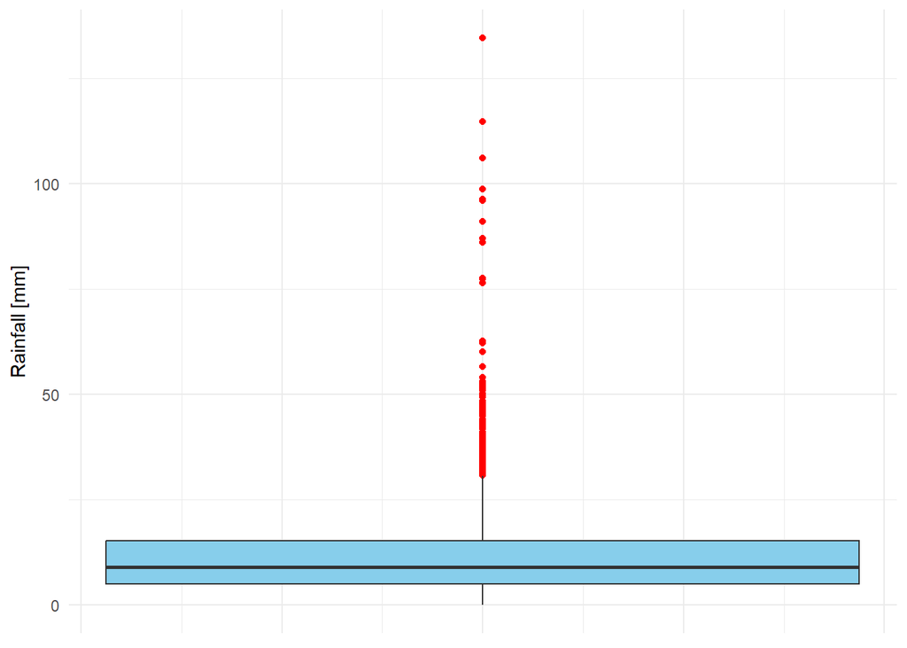

```r
rainfall = df_rain$col2
rainfall = rainfall[rainfall > 0] # only include rainy days

ggplot(, aes( y = rainfall)) +
  geom_boxplot(outlier.color = "red", outlier.shape = 16, fill = "skyblue") +
  labs(y = "Rainfall [mm]") +  # Set the y-axis label
  theme_minimal() +
  theme(axis.text.x = element_blank(),  # Remove x-axis labels
        axis.ticks.x = element_blank())  # Remove x-axis ticks
```

```r
# use the base R functions to get the values
print(mean(rainfall))
```

```
## [1] 12.14037
```

```r
print(var(rainfall))
```

```
## [1] 136.5042
```

```r
print(median(rainfall))
```

```
## [1] 8.977
```

```r
print(quantile(rainfall,c(0.25,0.50,0.75)))
```

```
##    25%    50%    75%
##  4.882  8.977 15.205
```

```r
print(paste(max(rainfall), min(rainfall)))
```

```
## [1] "134.538 0.002"
```

#### 0.4 Theoretical distributions

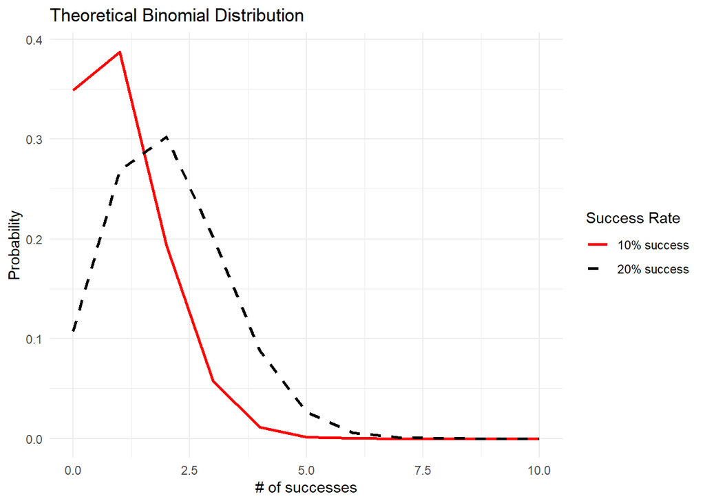

```r
# Binomial distribution

# Parameters
event_space <- 0:10  # One lion hunting 10 times
p1 <- 0.1            # 10% success rate
p2 <- 0.2            # 20% success rate
n <- 10              # 10 trials

# Compute probabilities
y1 <- dbinom(event_space, size = n, prob = p1)
y2 <- dbinom(event_space, size = n, prob = p2)

ggplot() +
  geom_line(aes(x = event_space, y = y1,
                color = "10% success",
                linetype = "10% success"), linewidth = 1) +
  geom_line(aes(x = event_space, y = y2,
                color = "20% success",
                linetype = "20% success"), linewidth = 1) +
  labs(
    x = "# of successes", y = "Probability",
    title = "Theoretical Binomial Distribution",
    color = "Success Rate",      # Legend title for color
    linetype = "Success Rate"    # Legend title for line type
  ) +
  scale_color_manual(
    values = c("10% success" = "red", "20% success" = "black")
  ) +
  scale_linetype_manual(
    values = c("10% success" = "solid", "20% success" = "dashed")
  ) +
  guides(
    color = guide_legend(order = 1),
    linetype = guide_legend(order = 1) # try to change order = 1 to order = 2 and see what happens
  ) +
  theme_minimal()
```

```r
# Poisson distribution

census_filename <- './lab1_census.csv'

# Luquillo census data, full 16ha
df_census = read_csv(census_filename,show_col_types=FALSE)
print(colnames(df_census))
```

```
## [1] "X"                     "Y"                     "SPECIES"
## [4] "dbh_c1_cm"             "dbh_c2_cm"             "plant_functional_type"
```

```r
# Generate K quadrats based on X and Y

# Set parameters
K <- 200
set.seed(1)  # For reproducibility
X <- runif(K, min = 0, max = 320)
Y <- runif(K, min = 0, max = 500)
# runif is to generate random number from uniform distribution

N_bigtree <- numeric(K)  # Initialize an empty numeric vector with the length of K
dbh_threshold <- 50

# Loop over each quadrat
for (i in seq_len(K)) {
  # Apply the data mask to filter the census data
  data_mask <- with(df_census,
    X < X[i] + 10 & X >= X[i] - 10 &
    Y < Y[i] + 10 & Y >= Y[i] - 10
  )

  # Subset the data for the current quadrat
  df_quadrat <- df_census[data_mask, ]

  # Count the number of "big trees"
  N_bigtree[i] <- sum(df_quadrat$dbh_c1_cm > dbh_threshold, na.rm = TRUE)
}
```

```r
# Load the necessary package for distribution fitting
library(MASS)
# Fit a Poisson distribution to the data
fit_result <- fitdistr(N_bigtree, "poisson",lower=0,upper=5)

# Print the parameter of the Poisson distribution
lambda <- fit_result$estimate["lambda"]
cat("Lambda (Poisson parameter):", lambda, "\n")
```

```
## Lambda (Poisson parameter): 0.81
```

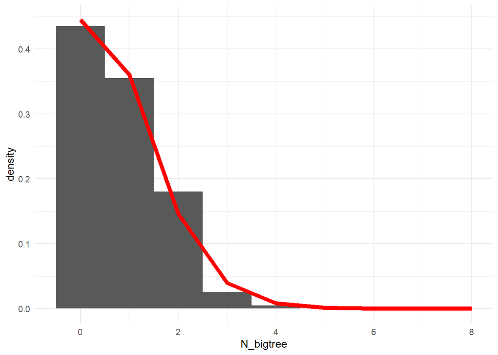

```r
# Overlay the theoretical PMF
x <- seq(0,8, by=1)
y <- dpois(x, lambda)

# Create a observed histogram
ggplot() +
  geom_histogram(aes(x=N_bigtree,y=after_stat(density)),breaks=x-0.5) +
  # there are many ways to define the bins in histogram,
  # and breaks define the bin boundaries
  # we shift the breaks by -0.5 to avoid data falling on edges
  geom_line(aes(x,y),linewidth=2,col="red") +
  theme_minimal()
```

### 1. I/O and column manipulations

We will use individual tree [spring phenology data at Harvard Forest](https://harvardforest1.fas.harvard.edu/exist/apps/datasets/showData.html?id=hf003) in this section

```r
df_phen = read_csv('./HF_spring_phenology.csv')
print(head(df_phen,10))
```

```
## # A tibble: 10 × 7
##     year tree.id species bb.doy l75.doy fbb.doy fopn.doy
##    <dbl> <chr>   <chr>    <dbl>   <dbl>   <dbl>    <dbl>
##  1  1990 ACPE-01 ACPE       121     145     136      136
##  2  1991 ACPE-01 ACPE       119     148     124      129
##  3  1992 ACPE-01 ACPE       134     154     134      138
##  4  1993 ACPE-01 ACPE       116     142     130      130
##  5  1994 ACPE-01 ACPE       121     144     134      135
##  6  1995 ACPE-01 ACPE       126     145     134      138
##  7  1996 ACPE-01 ACPE       125     147     136      141
##  8  1997 ACPE-01 ACPE       129     151     138      141
##  9  1998 ACPE-01 ACPE       111     133     122      125
## 10  1999 ACPE-01 ACPE       120     138      NA       NA
```

```r
# Rename columns
df_phen <- rename(df_phen,
                  tree_id = tree.id,
                  bb_doy = bb.doy,
                  fbb_doy = fbb.doy)

print(colnames(df_phen))
```

```
## [1] "year"     "tree_id"  "species"  "bb_doy"   "l75.doy"  "fbb_doy"  "fopn.doy"
```

```r
# add a new column as the difference between
# leaf budburst and flower budburst date

df_phen$fbb_minus_bb = df_phen$fbb_doy - df_phen$bb_doy

# alternatively
df_phen = mutate(df_phen,fbb_minus_bb = fbb_doy - bb_doy)
```

```r
# subset columns and then save
df_phen <- df_phen[,c("year","tree_id","species","bb_doy","fbb_doy","fbb_minus_bb")]

# alternatively
df_phen <- df_phen %>%
            dplyr::select(year,tree_id,species,bb_doy,fbb_doy,fbb_minus_bb)
# specify the select function from dplyr package
# because there are several functions named select in different packages

write_csv(df_phen,'./lab1_phenology.csv')
```

### 2. Indexing, subsetting, and grouping

In data analysis and validation, we often need to get a subset of the full table either across the rows, the columns or both. For example, we often want to clean the data by removing all NaN values. These operations require familiarity with indexing (accessing specific row/columns), subsetting, and grouping (group rows based on certain values).

In this section, we will introduce efficient ways to complete these tasks by working with `df_phen`

```r
# first explore the data, we will notice that there are some NaN values
print(head(df_phen,20))
```

```
## # A tibble: 20 × 6
##     year tree_id species bb_doy fbb_doy fbb_minus_bb
##    <dbl> <chr>   <chr>    <dbl>   <dbl>        <dbl>
##  1  1990 ACPE-01 ACPE       121     136           15
##  2  1991 ACPE-01 ACPE       119     124            5
##  3  1992 ACPE-01 ACPE       134     134            0
##  4  1993 ACPE-01 ACPE       116     130           14
##  5  1994 ACPE-01 ACPE       121     134           13
##  6  1995 ACPE-01 ACPE       126     134            8
##  7  1996 ACPE-01 ACPE       125     136           11
##  8  1997 ACPE-01 ACPE       129     138            9
##  9  1998 ACPE-01 ACPE       111     122           11
## 10  1999 ACPE-01 ACPE       120      NA           NA
## 11  2000 ACPE-01 ACPE       125     128            3
## 12  2001 ACPE-01 ACPE       123      NA           NA
## 13  2002 ACPE-01 ACPE       110     128           18
## 14  2003 ACPE-01 ACPE       127     132            5
## 15  2004 ACPE-01 ACPE       122     123            1
## 16  2005 ACPE-01 ACPE       128     132            4
## 17  2006 ACPE-01 ACPE       122     126            4
## 18  2007 ACPE-01 ACPE       126     130            4
## 19  2008 ACPE-01 ACPE       122     130            8
## 20  2009 ACPE-01 ACPE       119     119            0
```

```r
# let's count how many valid values are there for flower budburst dates
valid_num <- sum(is.finite(df_phen$fbb_doy))

# Count the number of NaN values
nan_num <- sum(is.na(df_phen$fbb_doy))

# Print the results
print(valid_num)
```

```
## [1] 975
```

```r
print(nan_num)
```

```
## [1] 1631
```

```r
# if we want to access the 5th to the 10th row
df_sub <- df_phen[5:10,]
print(df_sub)
```

```
## # A tibble: 6 × 6
##    year tree_id species bb_doy fbb_doy fbb_minus_bb
##   <dbl> <chr>   <chr>    <dbl>   <dbl>        <dbl>
## 1  1994 ACPE-01 ACPE       121     134           13
## 2  1995 ACPE-01 ACPE       126     134            8
## 3  1996 ACPE-01 ACPE       125     136           11
## 4  1997 ACPE-01 ACPE       129     138            9
## 5  1998 ACPE-01 ACPE       111     122           11
## 6  1999 ACPE-01 ACPE       120      NA           NA
```

```r
# now let's filter out all rows containing NaN values for fbb_doy

df_valid <- df_phen %>% drop_na(fbb_doy)
# if there is no specified column, the drop_na function
# will remove rows that has NaN in any columns

print(dim(df_valid)) # check how many data remains
```

```
## [1] 975   6
```

```r
# we would like to focus on fbb_doy, so let's remove the entire column of bb_doy
df_valid = df_valid %>% dplyr::select(-bb_doy)
print(colnames(df_valid))
```

```
## [1] "year"         "tree_id"      "species"      "fbb_doy"      "fbb_minus_bb"
```

In addition to filter NaN values, we often need to find a subset of the table based on values. For instance, how can we get a table for species `ACPE` (striped maple, *Acer pensylvanicum*) in year 2005?

```r
df_sub = df_valid %>% filter(species == "ACPE" & year == 2005)

## alternatively if you want to use a query string, you can run the following
## Define the query conditions
#query_str <- quote(species == "ACPE" & year == 2005)
## Use filter() to subset the data frame
#df_sub <- df_valid %>% filter(!!query_str)

print(df_sub)
```

```
## # A tibble: 2 × 5
##    year tree_id species fbb_doy fbb_minus_bb
##   <dbl> <chr>   <chr>     <dbl>        <dbl>
## 1  2005 ACPE-01 ACPE        132            4
## 2  2005 ACPE-02 ACPE        132            0
```

Now let’s consider a more complex scenario, we would like to calculate the mean flower budburst date for **each** species in the data set. We can use the grouping functionality

```r
df_mean <- df_valid %>%
  group_by(species) %>%
  summarize(mean_fbb = mean(fbb_doy, na.rm = TRUE))

print(df_mean)
```

```
## # A tibble: 30 × 2
##    species mean_fbb
##    <chr>      <dbl>
##  1 ACPE        131.
##  2 ACRU        103.
##  3 ACSA        117.
##  4 AMSP        120.
##  5 ARSP        130.
##  6 BEAL        124.
##  7 BELE        130.
##  8 BEPA        126.
##  9 BEPO        131.
## 10 COAL        151.
## # ℹ 20 more rows
```

```r
# we now get a new table that records the mean flower budburst date
```

```r
# we can also conduct nested grouping
# say we would like to calculate average flower budburst for each species
# in each year

df_mean <- df_valid %>%
  group_by(species,year) %>%
  summarize(mean_fbb = mean(fbb_doy, na.rm = TRUE))
print(df_mean)
```

```
## # A tibble: 407 × 3
## # Groups:   species [30]
##    species  year mean_fbb
##    <chr>   <dbl>    <dbl>
##  1 ACPE     1990     142.
##  2 ACPE     1991     126
##  3 ACPE     1992     138.
##  4 ACPE     1993     130
##  5 ACPE     1994     132.
##  6 ACPE     1995     137.
##  7 ACPE     1996     139
##  8 ACPE     1997     142.
##  9 ACPE     1998     125
## 10 ACPE     1999     144
## # ℹ 397 more rows
```

#### Practice 1

Finish the following tasks based on the template above (and online search if needed):

- Read in the `lab1_phenology.csv` that you have saved before.
- Remove all NaN values in leaf budburst date `bb_doy`, report the number of records/rows remain
- Calculate the average leaf budburst date (`bb_doy`) for `FAGR` (*Fagus grandifolia*, American Beech) for **each** year. Report the median of leaf budburst date across all years. Plot a boxplot of the inter-annual variation of its budburst dates
- Calculate the multi-year average leaf budburst date for all species and plot a histogram of the cross-species variation in average budburst dates
- Find out which species has the latest leaf budburst date within the dataset.

#### Practice 2

Finish the following tasks based on the template above (and online search if needed):

- Read the `lab1_census.csv` data
- Assign each row/record to a 20m by 20m subplot based on `X` and `Y` coordinates. Specifically, X dimension goes from 0-320, Y dimension goes from 0-500. Therefore, 0-20m in X and 0-20m in Y is one subplot and 20-40m in X and 0-20m in Y is another subplot. There should be 400 subplots (16 * 25). Come up with your own subplot naming system and create a new column called `subplot_ID` to record the subplot for each tree/record/row.
- Using the data above, calculate how many >10cm (using column `dbh_c1_cm`) trees are there in **each** subplot and save it as a dataframe, and this new dataframe should contain two columns (`subplot_ID` and `tree_num`)
- Plot the distribution of the number of >10cm trees across subplots using the new dataframe. Report its mean and standard deviation. What kind of theoretical distribution does it look like?